# HW Assignment 2

MUSA 508 Super Group

15 September 2023

# Setup

### Cleaning Workspace & Setup

This analysis used R’s `tidyverse`, `tidycensus`, `kableExtra`, and `sf` packages. In our setup, we load the libraries and set some options for a specific color ramp or preventing scientific notation.

```r
library(tidyverse)
library(tidycensus)
library(kableExtra)
library(sf)

# ignore scientific notation
options(scipen=999)
# ensure geometry is in sf format
options(tigris_class="sf")
# set colors for 5 color ramp in palette5
palette5 <- c("#f0f9e8","#bae4bc","#7bccc4","#43a2ca","#0868ac")

# set source url to grab functions from MUSA 5080 book
source("https://raw.githubusercontent.com/urbanSpatial/Public-Policy-Analytics-Landing/master/functions.r")

# Timothy's api key: "89824ea2e775e055d3b39974bbc07de16215f217"
census_api_key(Sys.getenv("CENSUS_API_KEY"), overwrite = TRUE)
```

### Use `get_acs()` to get 2016 ACS data

```r
tracts16 <-
  get_acs(geography = "tract",
          variables = c("B25026_001E","B02001_002E",
                        "B15001_050E","B15001_009E",
                        "B19013_001E", "B25058_001E",
                        "B06012_002E"),
          year=2016, state="DC", geometry=TRUE) %>%
  st_transform('ESRI:102685')
```

#### Wide data vs long data (and `spread`vs `gather`)

We create a new data frame consisting only of population

```r
totalPop16 <-
  tracts16 %>%
  filter(variable == "B25026_001")
```

### Using ggplot to map census data with {sf}

Consult the textbook to understand the symbology schemes.

(Note: the `qBr()` function used here is an update to the one used version used in the text book so the results may appear different.)

```r
A <-
  ggplot() +
  geom_sf(data = totalPop16, aes(fill = estimate)) +
  theme(
    plot.title = element_text(size=22)
    )

B <-
  ggplot() +
  geom_sf(data = totalPop16, aes(fill = q5(estimate))) +
  theme(plot.title = element_text(size=22))

C <-
  ggplot() +
  geom_sf(data = totalPop16, aes(fill = q5(estimate))) +
  scale_fill_manual(values = palette5,
                    labels = qBr(totalPop16, "estimate"),
                    name = "Total\nPopluation\n(Quintile Breaks)") +
  theme(plot.title = element_text(size=22))

D <-
  ggplot() +
  geom_sf(data = totalPop16, aes(fill = q5(estimate))) +
  scale_fill_manual(values = palette5,
                    labels = qBr(totalPop16, "estimate"),
                    name = "Popluation\n(Quintile Breaks)") +
  labs(title = "Total Population", subtitle = "Washington D.C.; 2016") +
  mapTheme() +
  theme(plot.title = element_text(size=22))
```

### Working with ACS Data

Here we will modify the 2016 ACS by using `spread()` to widen the data so that each census variable is now a column. We will use `rename()` to give sensible names to the columns and we will use `mutate()` to make new features out of the existing columns. These are all steps we had introduced in Lab 1, except here we are doing it on {sf} spatial data frames.

```r
# Let's "spread" the data into wide form

tracts16 <-
  tracts16 %>%
  dplyr::select( -NAME, -moe) %>%
  spread(key = variable, value = estimate) %>%
  rename(TotalPop = B25026_001,
         Whites = B02001_002,
         FemaleBachelors = B15001_050,
         MaleBachelors = B15001_009,
         MedHHInc = B19013_001,
         MedRent = B25058_001,
         TotalPoverty = B06012_002)


# Let's create new rate variables using mutate

tracts16 <-
  tracts16 %>%
  mutate(pctWhite = ifelse(TotalPop > 0, Whites / TotalPop, 0),
         pctBachelors = ifelse(TotalPop > 0, ((FemaleBachelors + MaleBachelors) / TotalPop), 0),
         pctPoverty = ifelse(TotalPop > 0, TotalPoverty / TotalPop, 0),
         year = "2016") %>%
  dplyr::select(-Whites,-FemaleBachelors,-MaleBachelors,-TotalPoverty)
```

Tracts 2016 is now complete. Let’s grab 2020 tracts and do the same thing.

### 2020 Census Data

Notice that we are getting “wide” data here in the first place This saves us the trouble of using “spread”. We do this by using the `output="wide"` argument to `get_acs()`. IN previous code chunks we split the use of `get_acs()` to download the data from the use of `mutate()` and other {dplyr} functions. Here we put the entire process into one continuous sequence of code using the “pipe” operator `%>%`.

```r
tracts20 <-
  get_acs(geography = "tract",
          variables = c("B25026_001E","B02001_002E",
                        "B15001_050E","B15001_009E",
                        "B19013_001E","B25058_001E",
                        "B06012_002E"),
          year=2020, state="DC",
          geometry=TRUE, output="wide") %>%
  st_transform('ESRI:102685') %>%
  rename(TotalPop = B25026_001E,
         Whites = B02001_002E,
         FemaleBachelors = B15001_050E,
         MaleBachelors = B15001_009E,
         MedHHInc = B19013_001E,
         MedRent = B25058_001E,
         TotalPoverty = B06012_002E) %>%
  dplyr::select(-NAME, -starts_with("B")) %>%
  mutate(pctWhite = ifelse(TotalPop > 0, Whites / TotalPop,0),
         pctBachelors = ifelse(TotalPop > 0, ((FemaleBachelors + MaleBachelors) / TotalPop),0),
         pctPoverty = ifelse(TotalPop > 0, TotalPoverty / TotalPop, 0),
         year = "2020") %>%
  dplyr::select(-Whites, -FemaleBachelors, -MaleBachelors, -TotalPoverty)
```

## allTracts Creation

```r
allTracts <- rbind(tracts16,tracts20)
```

# Code and notes for HW2

## Pulling census tracts and ACS data for 2009 and 2017 (?)

```r
tracts09 <-
  get_acs(geography = "tract",
          variables = c("B25026_001E","B02001_002E",
                        "B15001_050E","B15001_009E",
                        "B19013_001E","B25058_001E",
                        "B06012_002E"),
          year=2009, state="DC",
          geometry=TRUE, output="wide") %>%
  st_transform('ESRI:102685') %>%
  rename(TotalPop = B25026_001E,
         Whites = B02001_002E,
         FemaleBachelors = B15001_050E,
         MaleBachelors = B15001_009E,
         MedHHInc = B19013_001E,
         MedRent = B25058_001E,
         TotalPoverty = B06012_002E) %>%
  dplyr::select(-NAME, -starts_with("B")) %>%
  mutate(pctWhite = ifelse(TotalPop > 0, Whites / TotalPop,0),
         pctBachelors = ifelse(TotalPop > 0, ((FemaleBachelors + MaleBachelors) / TotalPop),0),
         pctPoverty = ifelse(TotalPop > 0, TotalPoverty / TotalPop, 0),
         year = "2009") %>%
  dplyr::select(-Whites, -FemaleBachelors, -MaleBachelors, -TotalPoverty)
```

```r
tracts17 <-
  get_acs(geography = "tract",
          variables = c("B25026_001E","B02001_002E",
                        "B15001_050E","B15001_009E",
                        "B19013_001E","B25058_001E",
                        "B06012_002E"),
          year=2017, state="DC",
          geometry=TRUE, output="wide") %>%
  st_transform('ESRI:102685') %>%
  rename(TotalPop = B25026_001E,
         Whites = B02001_002E,
         FemaleBachelors = B15001_050E,
         MaleBachelors = B15001_009E,
         MedHHInc = B19013_001E,
         MedRent = B25058_001E,
         TotalPoverty = B06012_002E) %>%
  dplyr::select(-NAME, -starts_with("B")) %>%
  mutate(pctWhite = ifelse(TotalPop > 0, Whites / TotalPop,0),
         pctBachelors = ifelse(TotalPop > 0, ((FemaleBachelors + MaleBachelors) / TotalPop),0),
         pctPoverty = ifelse(TotalPop > 0, TotalPoverty / TotalPop, 0),
         year = "2017") %>%
  dplyr::select(-Whites, -FemaleBachelors, -MaleBachelors, -TotalPoverty)
```

## UnConverted Code: ‘Wrangling Transit Open Data’ Forward

## Tried writing something to pull DC metro stations based on code for SEPTA stops - Jamie

### Added in Metro lines - Timothy

```r
#no idea if this works yet... need to test
metroStops <- st_read("https://maps2.dcgis.dc.gov/dcgis/rest/services/DCGIS_DATA/Transportation_Rail_Bus_WebMercator/MapServer/52/query?outFields=*&where=1%3D1&f=geojson") %>%
    dplyr::select(NAME, LINE) %>%
  st_transform(st_crs(tracts20)) # change tracts20 to tracts## based on years used

metroLines <- st_read("https://maps2.dcgis.dc.gov/dcgis/rest/services/DCGIS_DATA/Transportation_Rail_Bus_WebMercator/MapServer/106/query?outFields=*&where=1%3D1&f=geojson") %>%
    dplyr::select(NAME, GIS_ID) %>%
  st_transform(st_crs(tracts20))
```

## View of Metro Stations & Lines

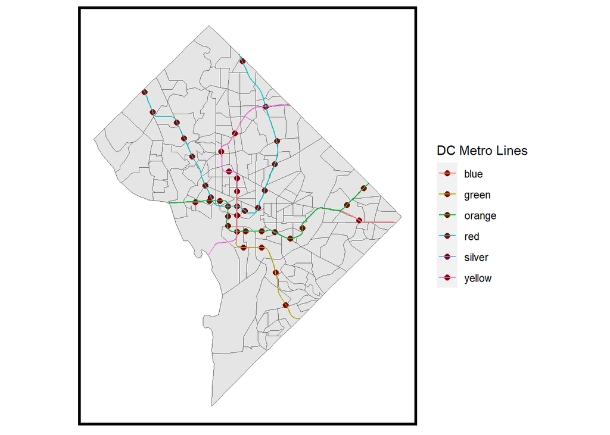

```r
ggplot() +
  geom_sf(data=tracts16)+
  geom_sf(data=metroStops, show.legend = "point", size=2,color = "#800000")+ # str_split(LINE,",",simplify=T)[1]) maybe (too many legend entries)
  geom_sf(data=metroLines, aes(color=NAME))+ # Why is color wrong, but it gets the right names?
  labs(color="DC Metro Lines")+
  mapTheme()
```

# ACS variable exploration

### Jamie’s notes

Dropping a sample code chunk here that fetches/mutates my variables of interest.

```r
tracts09 <-
  get_acs(geography = "tract",
          variables = c("B25026_001E","B02001_002E",
                        "B19013_001E","B25058_001E",
                        "B06012_002E",
                        "B05012_003E", "B25002_003E", #new ones begin here
                        "B25002_001E", "B25071_001E"),
          year=2009, state="DC",
          geometry=TRUE, output="wide") %>%
  st_transform('ESRI:102685') %>%
  rename(TotalPop = B25026_001E,
         Whites = B02001_002E,
         MedHHInc = B19013_001E,
         MedRent = B25058_001E,
         TotalPoverty = B06012_002E,
         ForeignBorn = B05012_003E, #new ones begin here
         TotalHHs = B25002_001E,
         VacantHHs = B25002_003E,
         RentBurden = B25071_001E
         ) %>%
  dplyr::select(-NAME, -starts_with("B")) %>%
  mutate(pctWhite = ifelse(TotalPop > 0, Whites / TotalPop,0),
         pctPoverty = ifelse(TotalPop > 0, TotalPoverty / TotalPop, 0),
         pctForeignBorn = ifelse(TotalPop > 0, ForeignBorn / TotalPop, 0),
         pctVacant = ifelse(TotalHHs > 0, VacantHHs / TotalHHs, 0),
         avgHHsize = ifelse(TotalHHs > 0, TotalPop / TotalHHs, 0),
         year = "2009") %>%
  dplyr::select(-Whites, -TotalPoverty, -VacantHHs)
```

To summarize the new variables: - RentBurden: median gross rent as a percentage of household income - pctForeignBorn: percent of population born outside the US - pctVacant: percent of households that are vacant

We can investigate this problem from multiple angles.

### Timothy’s code & notes

```r
## Need to get right variables still --different year has different variable name
# tracts_year <-
#   get_acs(geography = "tract",
#
#           #             Var ID          Intended Name for Column
#           variables = c("B25026_001E", # given var 1
#                         "B02001_002E", # given var 2
#                         "B15001_050E", # given var 3
#                         "B15001_009E", # given var 4
#                         "B19013_001E", # given var 5
#                         "B25058_001E", # given var 6
#                         "B06012_002E" # given var 7
#                          # Estimated Total Population by Detailed Race
#                         ),
#
#           year=2020, state="DC", geometry=TRUE) %>%
#   st_transform('ESRI:102685') %>% # Maryland's State Plane CS
#   rename(TotalPop = B25026_001E,
#          Whites = B02001_002E,
#          FemaleBachelors = B15001_050E,
#          MaleBachelors = B15001_009E,
#          MedHHInc = B19013_001E,
#          MedRent = B25058_001E,
#          TotalPoverty = B06012_002E
#          ) %>%
#   dplyr::select(-NAME, -starts_with("B")) %>%
#   mutate(pctWhite = ifelse(TotalPop > 0, Whites / TotalPop,0),
#          pctBachelors = ifelse(TotalPop > 0, ((FemaleBachelors + MaleBachelors) / TotalPop),0),
#          pctPoverty = ifelse(TotalPop > 0, TotalPoverty / TotalPop, 0),
#          year = "2020") %>%
#   dplyr::select(-Whites, -FemaleBachelors, -MaleBachelors, -TotalPoverty)
```